# Integrative Analysis of RNA-seq and ATAC-seq Data

Gene regulatory dynamics during embryogenesis in Cloeon dipterum

Maria Rossello

Last run: 26/04/2024

# Setting up project folders and libraries

This section outlines the initial setup. It involves loading specific R functions, setting up necessary libraries, and organizing data directories to streamline file management and data processing.

*Loading necessary functions.* This code chunk is responsible for importing custom R functions necessary for processing and analyzing ATAC-seq data. These functions are stored externally and are essential for the specific analyses that will be conducted in subsequent steps.

```r
# Load functions from a script located in the working directory for downstream analysis
source(paste0(wd,"/atac_downstrem_analysis_functions.R"))
```

*Loading required libraries.* A suite of R packages is loaded here, enabling data manipulation, visualization, and advanced statistical analysis

```r
# Load Libraries

## Libraries for Data Manipulation
library(dplyr)        # Provides a grammar for data manipulation, offering helpful verbs like mutate, select, filter.
library(tidyr)        # Facilitates data tidying, especially reshaping with pivot_longer and pivot_wider.

## Libraries for Data Input and String Operations
library(readr)        # Fast and friendly way to read rectangular data (like CSV, TSV).
library(stringr)      # Simplifies string operations, consistent, simple and fast string handling.

## Libraries for Data Visualization
library(ggplot2)      # A system for declaratively creating graphics, based on the Grammar of Graphics.
library(pheatmap)     # Simplifies creating heat maps and adjusting their fine details.
library(RColorBrewer) # Provides color schemes for maps and other graphics.
library(ggrepel)    # Helps with non-overlapping text labels on plots.
library(dendextend) # For enhancing dendrogram objects


# Load libraries for statistical analysis
library(edgeR)        # Analysis of differential expression of RNA-seq count data
library(stats)        # Contains functions for statistical calculations including clustering and correlation.

## Graphics Device Utilities
library(grDevices)    # Provides functions for handling colors and other graphic devices, crucial for creating and adjusting plots.
```

The input data directories are systematically organized to ensure easy access and management of data files necessary for the analysis:

- 0_EXPERIMENT_INFO: Contains metadata about the experiments, such as sample details, experimental conditions…
- 1_COUNTS: Stores count matrices.
- 2_PEAK_INFO: Includes information about genomic regions of open chromatin identified in the ATAC-seq data.
- 3_OTHER_SP_DATA: Holds comparative ATACseq data from other species that will be used for cross-species analysis. This data comes from publicly available data.
- 4_NATCOM2020_INFO: Specific mayfly genomic information coming from [Almudi *et al.,* 2020](https://doi.org/10.1038/s41467-020-16284-8).
- 5_RNA-SEQ: Directory for storing RNA-seq data files.

We save the paths to this folders in variables to acces them during all the analysis

```r
info  <- paste0(wd,"0_EXPERIMENT_INFO/")
counts  <- paste0(wd,"1_COUNTS/")
peak_info <- paste0(wd,"2_PEAK_INFO/")
sp_data <- paste0(wd,"3_OTHER_SP_DATA/")
natcom2020 <- paste0(wd,"4_NATCOM2020_INFO/")
rnaseq <- paste0(wd,"5_RNA-SEQ/")
```

The output data structure is geared towards organizing the results of the analysis into logical and functional directories, making it easier to locate and use the data in subsequent steps or for final reporting.

- A6_RNASEQ_INTEGRATION: This is the main folder designated for storing all outputs related to differential peak analysis. It acts as a central hub for aggregating analytical results. This will be designed as our analysis folder.
- output_images: A subfolder created within the main analysis folder to store all graphical representations produced during the analysis.
- output_files: This directory is reserved for statistical outputs, such as tables.

```r
analysis_folder <- paste0(wd,"A6_RNASEQ_INTEGRATION/")
imgdir  <- paste0(analysis_folder,"/output_images/")
statdir <- paste0(analysis_folder,"/output_files/")
```

# Importing and Organizing Data

## C. dipterum ATAC Data

To initiate our analysis of ATAC-seq data for *C. dipterum*, we begin by importing the sample information. This dataset includes essential details for each sample, crucial for the subsequent analyses.

```r
# Load the sample information from a CSV file
samples_info <- readr::read_delim(paste0(info, "info_samples.csv"),
                                  delim = ",",
                                  escape_double = FALSE,
                                  trim_ws = TRUE)
# Display the dataframe to verify its contents
samples_info
```

```
## # A tibble: 12 × 4
##    stage name                replicate sample
##    <chr> <chr>                   <dbl> <chr>
##  1 emb4  embryo_stage4_rep1          1 e4_1
##  2 emb4  embryo_stage4_rep2          2 e4_2
##  3 emb6  embryo_stage6_rep1          1 e6_1
##  4 emb6  embryo_stage6_rep6          2 e6_2
##  5 emb8  embryo_stage8_rep1          1 e8_1
##  6 emb8  embryo_stage8_rep2          2 e8_2
##  7 emb10 embryo_stage10_rep1         1 e10_1
##  8 emb10 embryo_stage10_rep2         2 e10_2
##  9 emb12 embryo_stage12_rep1         1 e12_1
## 10 emb12 embryo_stage12_rep2         2 e12_2
## 11 emb14 embryo_stage14_rep1         1 e14_1
## 12 emb14 embryo_stage14_rep2         2 e14_2
```

Given our focus on dynamic peaks identified in a previous analysis (see Downstream analysis 1: Quantitative Mapping of Open Chromatin Regions), we next load the normalized count data associated with these peaks:

```r
# Load normalized count data for dynamic samples
dynamic_sample <- readr::read_delim(paste0(counts, "dynamic_peaks_sample_norm.tsv"),
                                    delim = "\t", escape_double = FALSE,
                                    trim_ws = TRUE)
# Display the dataframe to verify its contents
head(dynamic_sample)
```

```
## # A tibble: 6 × 13
##   peak_id  e10_1 e10_2 e12_1 e12_2 e14_1 e14_2   e4_1  e4_2  e6_1  e6_2  e8_1
##   <chr>    <dbl> <dbl> <dbl> <dbl> <dbl> <dbl>  <dbl> <dbl> <dbl> <dbl> <dbl>
## 1 peak7    13.9   31.0  37.0 35.4  41.7   30.4   9.72  25.7  36.8 30.3  13.6
## 2 peak11    8.95  17.3  14.8  6.52 13.9   11.4 194.   157.  231.  87.7  29.4
## 3 peak20    8.95  22.8  15.7 25.1  35.8   33.2  11.9   28.8  23.8 14.6  11.5
## 4 peak26  158.    42.9  68.5 47.5   7.95  10.4  35.7   18.5  30.3 47.0  66.1
## 5 peak28   18.9   18.2  13.9 14.0  28.8   29.4  15.1   14.4  11.9  9.40 17.8
## 6 peak46   27.8   41.0  26.8 54.9  35.8   52.2  13.0   24.7  13.0 12.5   5.25
## # ℹ 1 more variable: e8_2 <dbl>
```

```r
# Load normalized count data for dynamic stages
dynamic_stage <- readr::read_delim(paste0(counts, "dynamic_peaks_stage.tsv"),
                                   delim = "\t", escape_double = FALSE,
                                   trim_ws = TRUE)
# Display the dataframe to verify its contents
head(dynamic_stage)
```

```
## # A tibble: 6 × 7
##   peak_id   emb10 emb12  emb14  emb4  emb6  emb8
##   <chr>     <dbl> <dbl>  <dbl> <dbl> <dbl> <dbl>
## 1 peak1000  33.5  49.2  102.   15.1  11.2   8.94
## 2 peak10000 38.8  46.9   47.4  10.6  24.9  34.7
## 3 peak10006 27.6  20.4   18.5  22.6  12.3  20.5
## 4 peak10021  3.27  1.85   2.46  2.68  2.11  7.89
## 5 peak10022 19.7   9.74   6.84 26.7  29.4  33.6
## 6 peak10025  5.10  1.86   6.28  3.16  6.97  4.73
```

Additionally, we load the gene associations for each peak, which are critical for functional genomic analysis:

```r
# Load gene associations for peaks
cdip_peak_associated_gene <- readr::read_delim(paste0(peak_info, "/clodip_embryoATAC_peak_to_gene.tsv"),
                                               delim = "\t", escape_double = FALSE,
                                               trim_ws = TRUE)
# Display the top rows of the dataframe to verify its contents
head(cdip_peak_associated_gene)
```

```
## # A tibble: 6 × 3
##   peak_id clodip_v3   zone
##   <chr>   <chr>       <chr>
## 1 peak1   clodip_v3_1 genebody
## 2 peak2   clodip_v3_1 genebody
## 3 peak3   <NA>        distal
## 4 peak4   <NA>        distal
## 5 peak5   clodip_v3_4 proximal
## 6 peak6   clodip_v3_4 genebody
```

## RNA-Seq Data

To supplement our ATAC-seq analysis with gene expression data, we import the RNA-seq counts. This data will allow us to compare gene expression levels with chromatin accessibility.

```r
# Load RNA-seq counts data, setting gene IDs as row names
rnaseq_counts <- readr::read_delim(paste0(rnaseq, "counts_rnaseq.tsv"),
                            delim = "\t", escape_double = FALSE,
                            trim_ws = TRUE)
rownames(rnaseq_counts) <- rnaseq_counts$gene_id
# Display the dataframe to verify the row names are set correctly
head(rnaseq_counts)
```

```
## # A tibble: 6 × 11
##   gene_id         e14_1 e14_2 e12_1 e12_2 e10_1 e10_2  e8_1  e6_1  e4_1  e4_2
##   <chr>           <dbl> <dbl> <dbl> <dbl> <dbl> <dbl> <dbl> <dbl> <dbl> <dbl>
## 1 clodip_v3_1      4810  4442  6183  5054 12057 11370 15904  2673  2365  3948
## 2 clodip_v3_10      536   542   501   602   464   580  1173   399   471  2249
## 3 clodip_v3_100      13    18    14    10     2     1     0     1     6    26
## 4 clodip_v3_1000   1523  1612  2125  2031  1851  1638   396   190   490   332
## 5 clodip_v3_10000  1722  1504  1194   793  1906  1754  3203  1980  2469  2805
## 6 clodip_v3_10001  7486  7299  8954 11193  2973  2813  3897  5177  4345  2152
```

# Parameters Setup

This section allows you to define key variables for your experiment and set aesthetic parameters for your graphs, making your analysis both rigorous and visually coherent.

## Cut Off

First, we set the statistical thresholds, crucial for determining significance in our differential analysis:

```r
# Setting minimum filter threshold
MIN_FILT = 10
```

```r
# Defining Fold Change and p-value thresholds for significance in the analysis
MIN_FC <- 2 # Fold Change threshold
MIN_PV <- 0.05 # p-value threshold
```

In this analysis we are using clustering methods for the dendograms. We save some of the methods that we want to test

```r
method <- c("euclidean", "maximum", "manhattan", "canberra", "binary" , "minkowski")
```

## Conditions to Study

Defining experimental conditions allows for targeted differential analysis across developmental stages. This block of code categorizes samples into developmental stages, which are crucial for comparing chromatin accessibility changes over time.

```r
# Creating a factor variable for the stages of development, which will be used in differential analysis
condition_factors <- factor(samples_info$stage,
                            levels=c("emb4","emb6","emb8","emb10", "emb12", "emb14"))

# Assigning the factor to a new column in samples_info for easy reference
samples_info$condition <- condition_factors
```

## Aesthetic Parameters

Important: To ensure your analysis runs smoothly and your graphs look exactly as intended, it’s crucial that the names you use in the following lists exactly match those defined in your data files. This consistency is key for linking your data correctly with the aesthetic elements like colors.

Now, let’s define some color parameters to keep our graphs looking consistent and visually appealing:

```r
# Defining color schemes for the conditions, ensuring they match those in samples_info$condition
condition_colors <- c("emb4"="#0072B2",
                      "emb6"="#009E73",
                      "emb8"="#D55E00",
                      "emb10"="#CC79A7",
                      "emb12"="#F0E442",
                      "emb14"="#56B4E9")

# Setting colors for individual samples within each condition
sample_colors <- c("e4_1"="#0072B2",
                   "e4_2"="#72C2FF",
                   "e6_1"="#009E73",
                   "e8_1"="#D55E00",
                   "e10_1"="#CC79A7",
                   "e10_2"="#FFB3D9",
                   "e12_1"="#F0E442",
                   "e12_2"="#FFFF99",
                   "e14_1"="#56B4E9",
                   "e14_2"="#99D6FF")

# Color coding for different peak zones
zone_colors <- c("promoter"="#DDC50F",
                 "proximal"="#228B22",
                 "genebody"="#4169E1",
                 "distal"="#984EA3")

# Additional color settings for states of the chromatin
state_colors <- c("open"="#48A9A6",
                  "closed"="#C97C5D",
                  "no-sig"="grey")
```

We also specify the order in which samples and stages should be arranged for visual consistency across figures:

```r
# Ordering of samples for plots
sample_order <- c("e4_1",
                  "e4_2",
                  "e6_1",
                  "e8_1",
                  "e10_1",
                  "e10_2",
                  "e12_1",
                  "e12_2",
                  "e14_1",
                  "e14_2")

# Mapping of stages to descriptive names
stage_order <- c("emb4"="Stage 4",
                 "emb6"="Stage 6",
                 "emb8"="Stage 8",
                 "emb10"="Stage 10",
                 "emb12"="Stage 12",
                 "emb14"="Stage 14")
```

# Counts

We begin our exploratory analysis by structuring the raw RNA-seq counts data. This step involves converting the dataframe to a matrix format, which facilitates more efficient computations in later steps.

```r
# Convert the RNA-seq count dataframe, excluding the first column (gene IDs), to a matrix
rnaseq_counts_m <- as.matrix(rnaseq_counts[,-1])
rownames(rnaseq_counts_m) <- rnaseq_counts$gene_id

#In this analysis we only have one replicate for stage6 and stage8. We filter that:
samples_info <- samples_info[samples_info$sample %in% colnames(rnaseq_counts_m),]
```

Next, we apply a filtering criterion to remove genes with low counts, which are less informative and can slow down downstream analyses.

```r
# Filter out rows with total counts not exceeding a minimum threshold
keep <- rowSums(rnaseq_counts_m) > MIN_FILT
rnaseq_counts_m <- rnaseq_counts_m[keep,]
```

This section emphasizes the preparation and initial analysis of sequencing count data to ensure a robust understanding of sample variability, essential for the subsequent normalization processes.

```r
# Create a DGEList object, which is integral for handling count data with associated sample information efficiently
dge <- DGEList(counts=as.matrix(rnaseq_counts_m),
               samples=samples_info,
               group=samples_info$condition)
```

To better understand the initial distribution of library sizes across samples, we compute and visualize these sizes.

```r
# Calculate and order library sizes for visualization purposes
library_sizes_df <- data.frame(sample=colnames(dge$counts),
                               libsize=colSums(dge$counts))
library_sizes_df <- names_to_graph(library_sizes_df, "sample", sample_order)
```

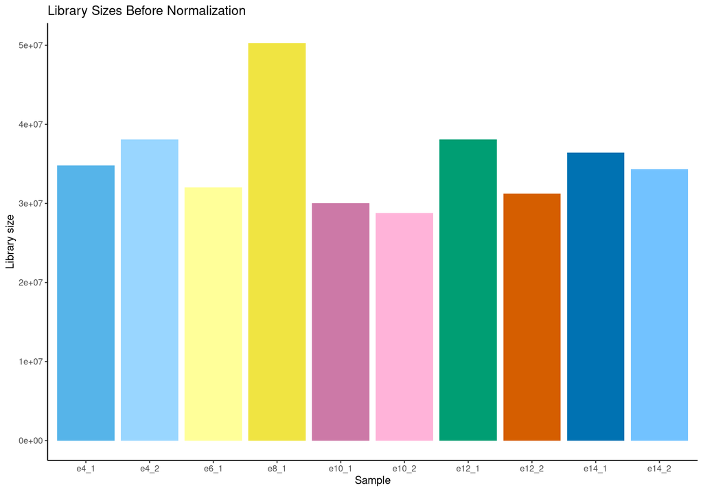

```r
# Plot the library sizes before normalization
libsize_plot <- ggplot(library_sizes_df, aes(x = sample, y = libsize)) +
  geom_bar(stat = "identity", fill = sample_colors) +
  theme_classic() +
  labs(title = "Library Sizes Before Normalization",
       x = "Sample",
       y = "Library size")
print(libsize_plot)
```

```r
# Save the initial library size plot to a file
save_ggplot(libsize_plot, "library_size_raw")
```

Recognizing discrepancies in library sizes, we apply normalization using the Trimmed Mean of M-values (TMM) method, which adjusts for library size and compositional differences across samples.

```r
# Normalize library sizes using the TMM method to account for library size and compositional biases
dge <- calcNormFactors(dge, method="TMM")
```

Finally, we save the normalized data as counts per million (CPM) for both log-transformed and untransformed data, enabling further analysis.

```r
# Calculate and save counts per million for further analysis
logCPM <- cpm(dge,
              normalized.lib.sizes = TRUE,
              log=TRUE,
              prior.count=3)
rownames(logCPM) <- rownames(rnaseq_counts_m)

CPM <- cpm(dge, log=FALSE)

logCPM_df <- data.frame(logCPM)
logCPM_df$gene_id <- rownames(rnaseq_counts_m)
```

## Sample Diversity

### Principal Component Analysis (PCA)

The PCA plot is instrumental in visualizing the overall variability among the samples by reducing the dimensionality of the data. This reduction helps to highlight patterns of similarity and divergence, which can be crucial for understanding biological differences.

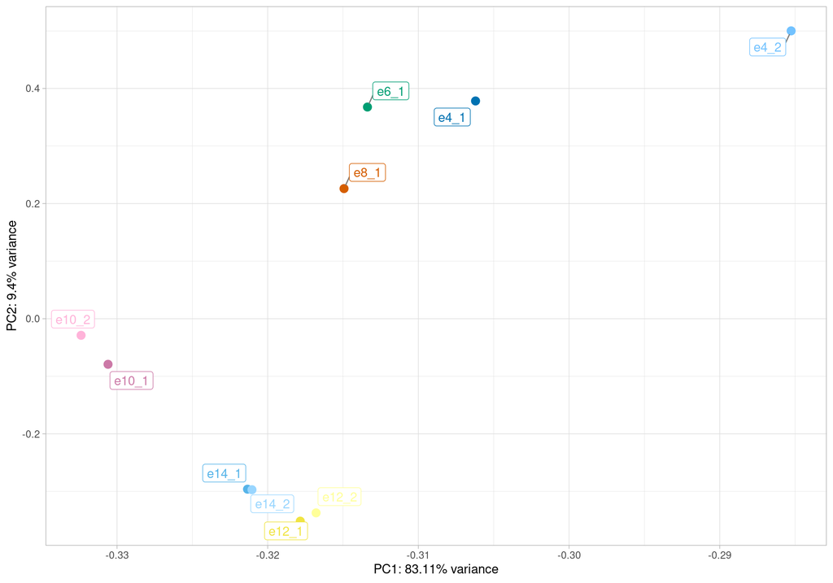

```r
# Perform PCA on the normalized counts matrix
pcaData <- prcomp(logCPM, scale=TRUE)
pcaData.df <- as.data.frame(pcaData$rotation)
percentVar <- round(summary(pcaData)$importance[2,]*100, 2)

# Label samples in the PCA plot
pcaData.df$sample <- as.factor(row.names(pcaData.df))

# Generate PCA plot
pca.expr_raw <- ggplot(pcaData.df, aes(x=PC1, y=PC2, color=sample, label=sample)) +
  geom_point(size=3) +
  scale_color_manual(values=sample_colors) +
  xlab(paste0("PC1: ", percentVar[1], "% variance")) +
  ylab(paste0("PC2: ", percentVar[2], "% variance")) +
  geom_label_repel(aes(label = sample),
                   box.padding   = 0.35,
                   point.padding = 0.5,
                   segment.color = 'grey50') +
  theme_light() +
  theme(legend.position="none")
print(pca.expr_raw)
```

```r
# Save the PCA plot
save_ggplot(pca.expr_raw, "pca")
```

PC1 and PC2 capture the primary sources of variation, highlighting significant axes of gene expression changes among samples. This visualization facilitates the identification of sample clusters with similar expression profiles, clearly distinguishing between early and late developmental stages.

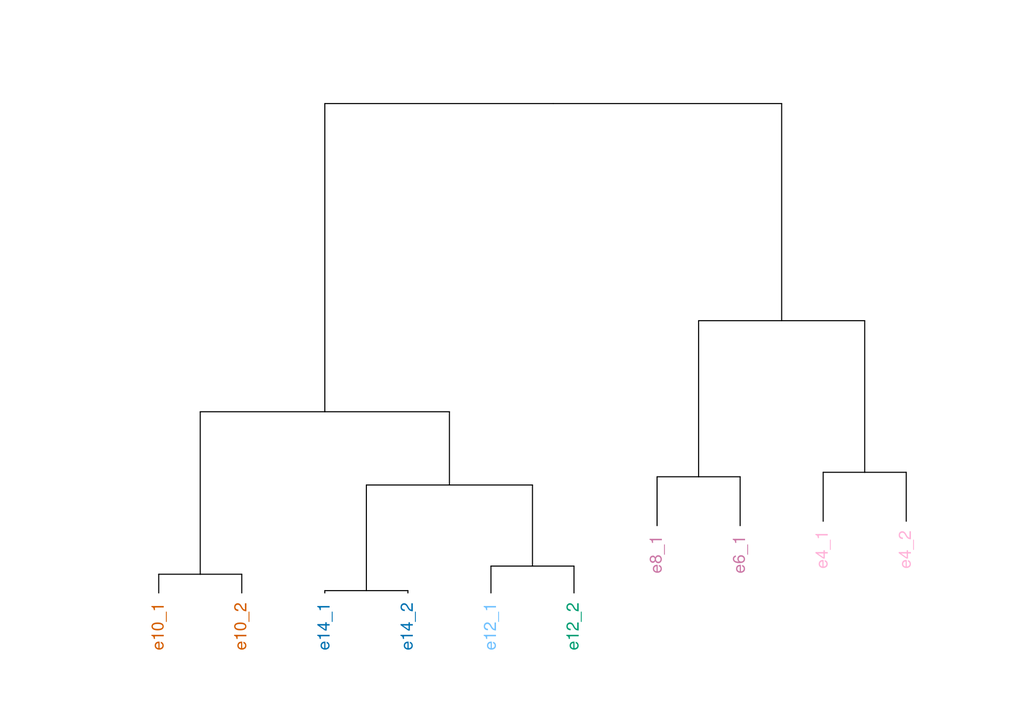

```r
# Calculate Spearman correlation-based distance matrix
dist <- as.dist(1 - cor(logCPM, method="spearman"))
distclust <- hclust(dist)

# Convert hierarchical clustering into a dendrogram and color code by developmental stage
dendrogram <- as.dendrogram(distclust, hang=0.1)
labels_colors(dendrogram) <- sample_colors[samples_info$condition][order.dendrogram(dendrogram)]

# Plot the dendrogram
dend_raw <- function(){
    plot(dendrogram,
         horiz = FALSE,
         yaxt='n', ann=FALSE)
}
dend_raw()
```

```r
# Save the dendrogram plot
save_ggplot(dend_raw(), "dendrogram")
```

This hierarchical clustering analysis helps identify which samples are more akin to each other, potentially indicating common regulatory mechanisms or stages of development. Like the PCA, it serves to discern clear groupings among the samples.

### Aggregation of Normalized Counts by Biological Stages

This section outlines the aggregation of normalized counts by biological stages, facilitating a focused analysis on stage-specific trends and variations. This process is critical for understanding differential gene expression across developmental stages.

```r
# Aggregate normalized counts by sample stage using custom functions for clearer data handling
logCPM_stage <- logCPM_df %>%
  pivot_longer(-gene_id, names_to = "sample", values_to = "norm_counts")  %>%
  mean_collapse_data_by_stage(samples_info=samples_info, df_to_collapse=., numeric_col="norm_counts") %>%
  dplyr::select(-sd) %>%
  pivot_wider(names_from = stage, values_from = mean) %>%
  data.frame()

# Save the mean data of normalized counts for each stage
write_delim(logCPM_stage,
            paste0(statdir, "logcpm_stage.tsv"),
            "\t")
```

```r
# Assign peak IDs as row names for the matrix of normalized counts by stage
logCPM_stage_matrix <- as.matrix(logCPM_stage[,-1])
rownames(logCPM_stage_matrix) <- logCPM_stage$gene_id
```

# Heat Maps of RNA-seq Counts

Heat maps are a powerful tool for visualizing complex data sets, allowing us to observe patterns of gene expression across different samples or conditions. This section details the creation of heat maps for all genes and specifically for dynamic peaks associated with differential gene expression.

#### Heat Map of All Genes

First, we generate a heat map for all genes using the matrix of log-transformed counts per million (logCPM) that are normalized by stage. This provides an overview of expression across all stages.

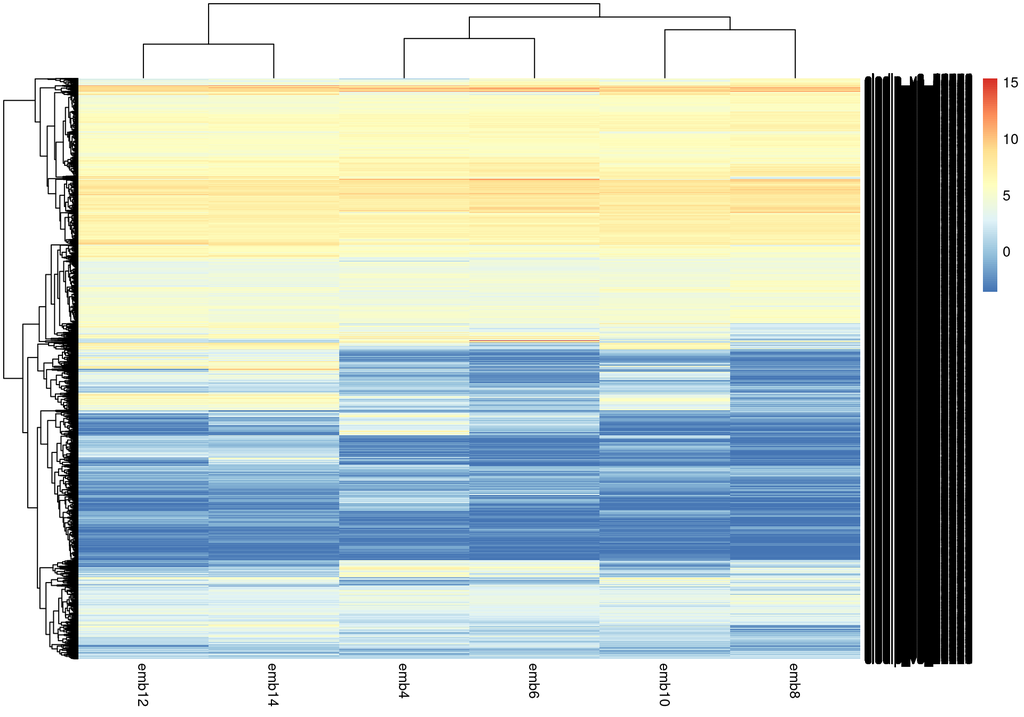

```r
# Create a basic heat map for all genes
heatmap_all <- pheatmap(logCPM_stage_matrix)
```

```r
# Save the heat map
save_ggplot(heatmap_all, "heatmap_dynamics_ordered_stage")
```

## Identification and Visualization of Dynamic Genes

Next, we focus on genes associated with dynamic peaks. These genes are crucial as they may exhibit significant changes in expression corresponding to developmental stages or experimental conditions.

```r
# Filter genes associated with dynamic peaks
dynamic_genes <- cdip_peak_associated_gene %>%
  dplyr::filter(peak_id %in% dynamic_stage$peak_id) %>%
  dplyr::select(clodip_v3) %>%
  dplyr::filter(!is.na(clodip_v3)) %>%
  dplyr::pull(clodip_v3)

# Subset the logCPM matrix to include only dynamic genes, ordered by stage
dynamic_genes_logcpm <- logCPM_stage_matrix[rownames(logCPM_stage_matrix) %in% dynamic_genes,]
dynamic_genes_logcpm <- dynamic_genes_logcpm[, names(stage_order)]
```

## Exploratory Heat Maps for Dynamic Peaks

We explore different clustering distances to best capture the inherent groupings within the dynamic genes.

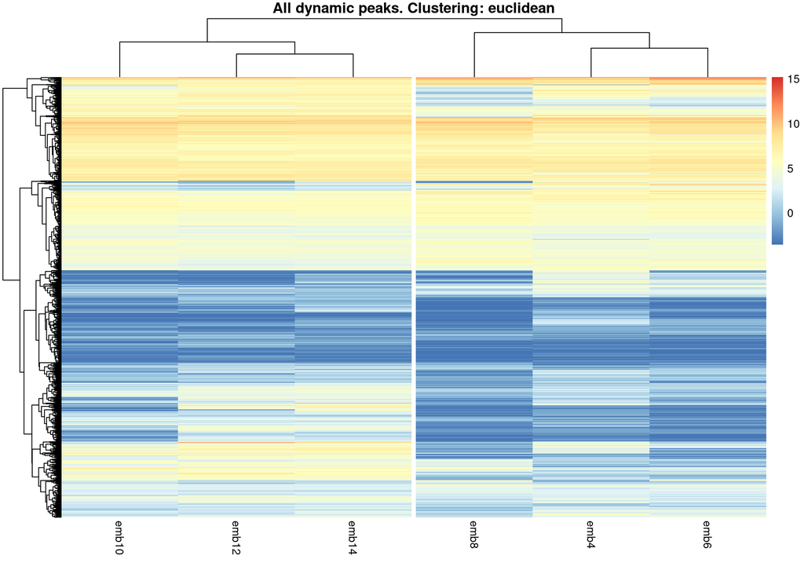

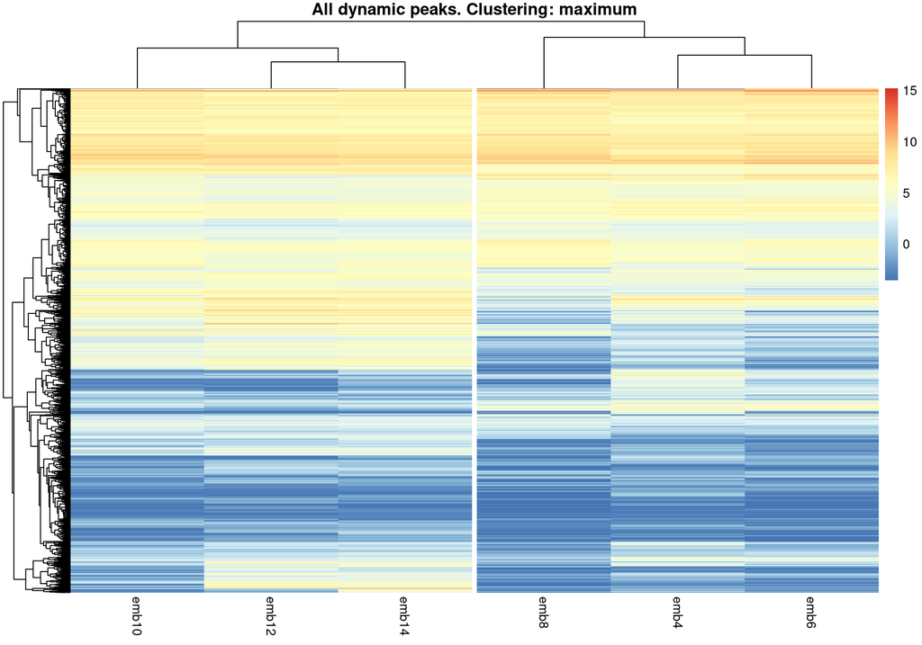

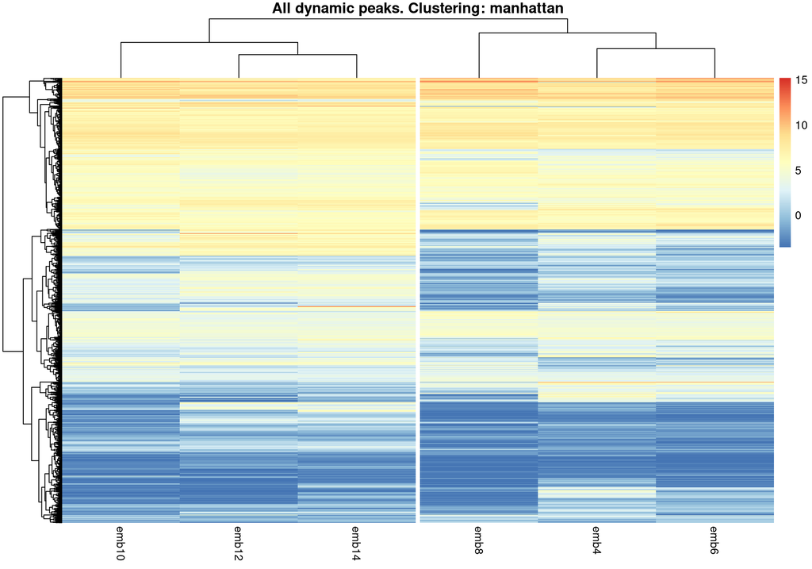

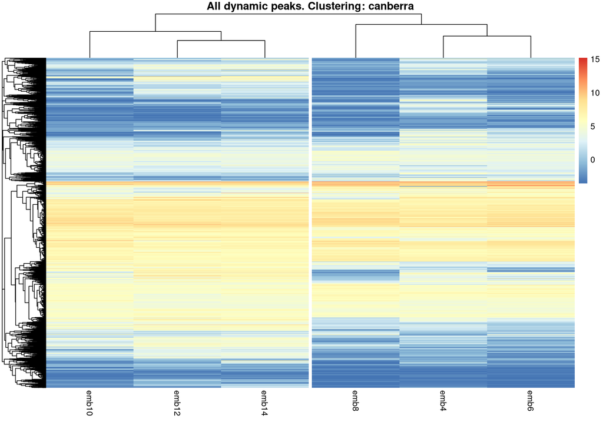

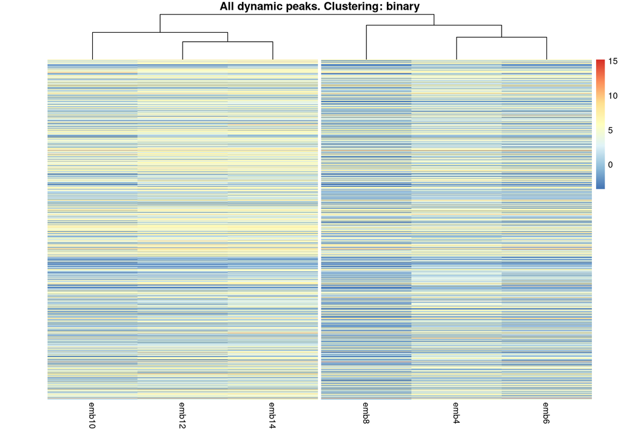

[figure not shown]

```r
# Explore clustering methods via heat maps
lapply(method, function(m){pheatmap::pheatmap(dynamic_genes_logcpm,
                                    cutree_cols=2,
                                    clustering_distance_rows = m,
                                    main=paste0("All dynamic peaks. Clustering: ", m),
                                    show_rownames=F)})
```

After selecting the optimal clustering method:

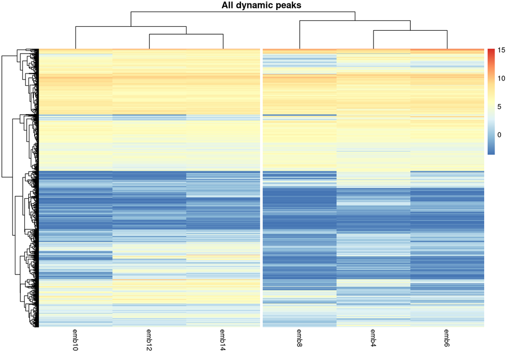

```r
# Final heat map using the selected clustering method
heatmap_dynamics <- pheatmap::pheatmap(dynamic_genes_logcpm,
         cutree_cols=2,
         clustering_distance_rows = "euclidean",
         main="All dynamic peaks",
         show_rownames=F)
```

```r
# Save the final heat map
save_ggplot(heatmap_dynamics, "heatmap_dynamics")
```

Sometimes, not clustering the columns can help in observing trends more related to the experimental design or conditions.

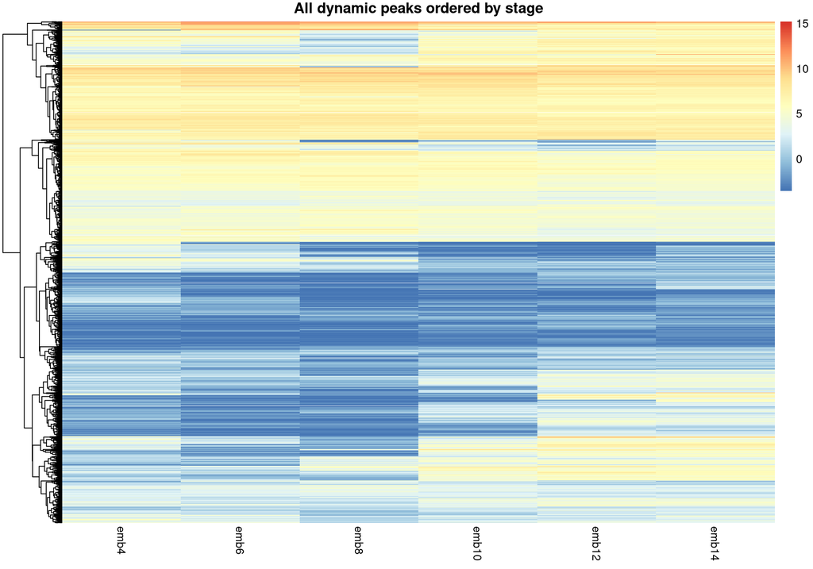

```r
# Heat map without clustering columns to observe stage-specific patterns
heatmap_dynamics_ordered_stage <- pheatmap::pheatmap(dynamic_genes_logcpm,
         cluster_cols = FALSE,
         clustering_distance_rows = "euclidean",
         main="All dynamic peaks ordered by stage",
         show_rownames=F)
```

```r
# Save the stage-ordered heat map
save_ggplot(heatmap_dynamics_ordered_stage, "heatmap_dynamics_ordered_stage")
```

To further dissect the relationships among dynamic genes, we apply clustering and annotate the heat map rows based on identified clusters.

```r
# Initialize a logical vector for row labeling
label_rows <- rep(FALSE, nrow(dynamic_genes_logcpm))

# Optionally, specify rows to label based on specific criteria (e.g., particular gene IDs)
# Uncomment the following line and adjust the gene IDs as needed
# label_rows[rownames(dynamic_genes_logcpm) %in% c("clodip_v3_1246", "clodip_v3_2467")] <- TRUE

# Generate labels for the rows, showing names for selected rows only
row_labels <- ifelse(label_rows, rownames(dynamic_genes_logcpm), "")
```

```r
# Determine the number of clusters and annotate rows accordingly
nclust <- 12
row_dendrogram <- heatmap_dynamics_ordered_stage$tree_row
clusters <- stats::cutree(row_dendrogram, k = nclust)

annotation_row <- data.frame(Clusters = factor(clusters))
rownames(annotation_row) <- names(clusters)

# Define colors for clusters
ann_colors <- setNames(colorRampPalette(brewer.pal(12, "Set3"))(nclust),
                       levels(annotation_row$Clusters))
```

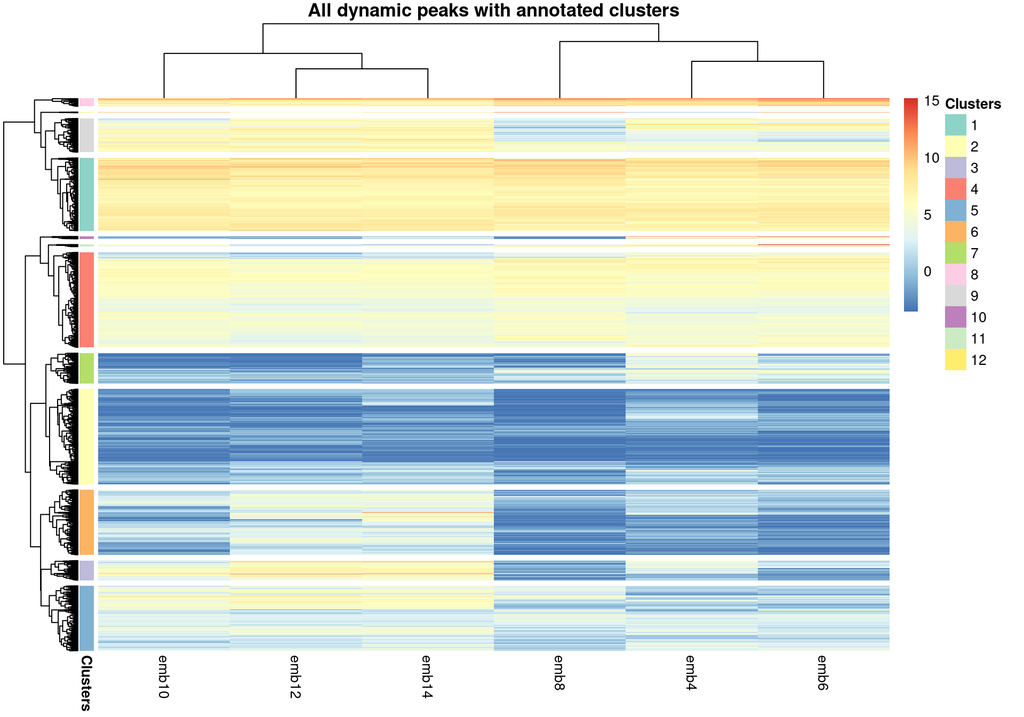

```r
# Heat map with row clustering and annotations
heatmap_dynamics_clustred <- pheatmap::pheatmap(dynamic_genes_logcpm,
         cutree_rows = nclust,
         clustering_distance_rows = "euclidean",
         labels_row = row_labels,
         annotation_row = annotation_row,
         annotation_colors = list(Clusters = ann_colors),
         main = "All dynamic peaks with annotated clusters")
```

```r
save_ggplot(heatmap_dynamics_clustred, "heatmap_dynamics_clustred")
```